# ml-jnd study II

Sheng Long

2023-06-13

# Hoffman Study II: Comparing distribution centers

Considers the following factors:

- size of the shift $d$ between the means of the distribution (*5 levels*):
  $$d = \{0.4, 0.6, 0.8, 1.0, 1.2\}$$
- size of the larger group (*3 levels*)
  $$n_1 = \{15, 45, 135\}$$
- ratio between smaller group and larger group (*3 levels*):
  $$\frac{n_2}{n_1}= \{\frac{1}{3}, \frac{2}{3} , \frac{3}{3}
  \}$$

For each ($d \times n_1 \times n_2$) we replicate it three times, resulting in $5 \times 3 \times 3 \times 3 = 135$ different data sets.

For each data set, we create 4 lineups, each corresponding to a particular design:

1. boxplot: `geom_boxplot()`
2. density plot: `geom_density()`
3. historgram: `geom_histogram()`
4. dotplots: `geom_jitter()`

This results in 135 data sets $\times$ 4 design types = $540$ lineups.

Each participant was shown 10 lineups, and one of the lineup was a reference chart.

- values are drawn from exponential distributions;
  - the first distribution has rate parameter $\lambda_1 = 1$
  - the second distribution has rate parameter $\lambda_2 = \frac{1}{d+1}$

Table 4 in the original paper says that they’ve fit a generalized linear mixed effects model using 2513 lineup evaluations by 208 participants.

- This number doesn’t quite add up … If each participant did 9 different lineups, this would result in 1872 evaluations, which is strictly smaller than 2513… but then again, the paper doesn’t really explain this experiment that well …

# Generating simulated data

```r
# define function that sets up data
gen_data <- function() {
  # set up parameters
  d <- 0.4 # 0.4, 0.6, 0.8, 1.0, 1.2
  n1 <- 15 # 15, 45, 135
  r <- 1/3 # 1/3, 2/3, 3/3
  n2 <- r * n1

  # Generate samples from exponential distribution
  s1 <- rexp(n1, rate = 1)
  s2 <- rexp(n2, rate = 1/(d + 1))

  # create dataframe
  df <- data.frame(Value = c(s1, s2),
                   Cat = c(rep("1",length(s1)), rep("2",length(s2))),
                   xseq = c(seq_along(s1),seq_along(s2)))
}
```

# Box plot

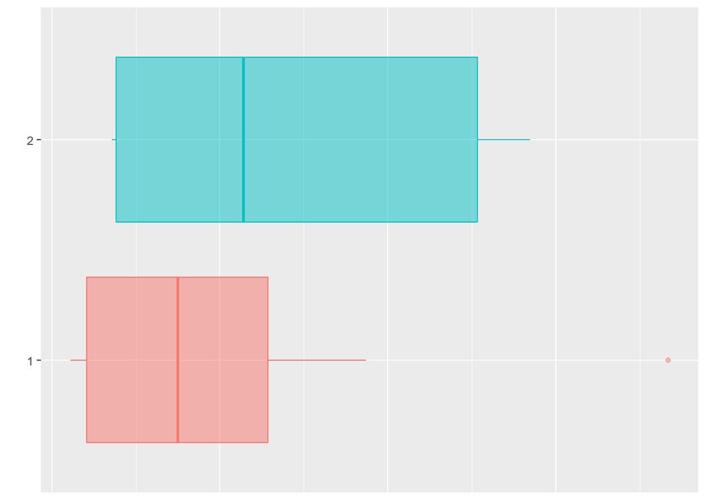

```r
df <- gen_data()
g <- ggplot(df, aes(x=Value, y=Cat, fill=Cat, color=Cat)) +
  geom_boxplot(alpha=.5, show.legend = FALSE) +
  xlab("") +
  ylab("") +
  theme(axis.title.x = element_blank(),
        axis.text.x = element_blank(),
        axis.ticks.x = element_blank())
g
```

# Density plot

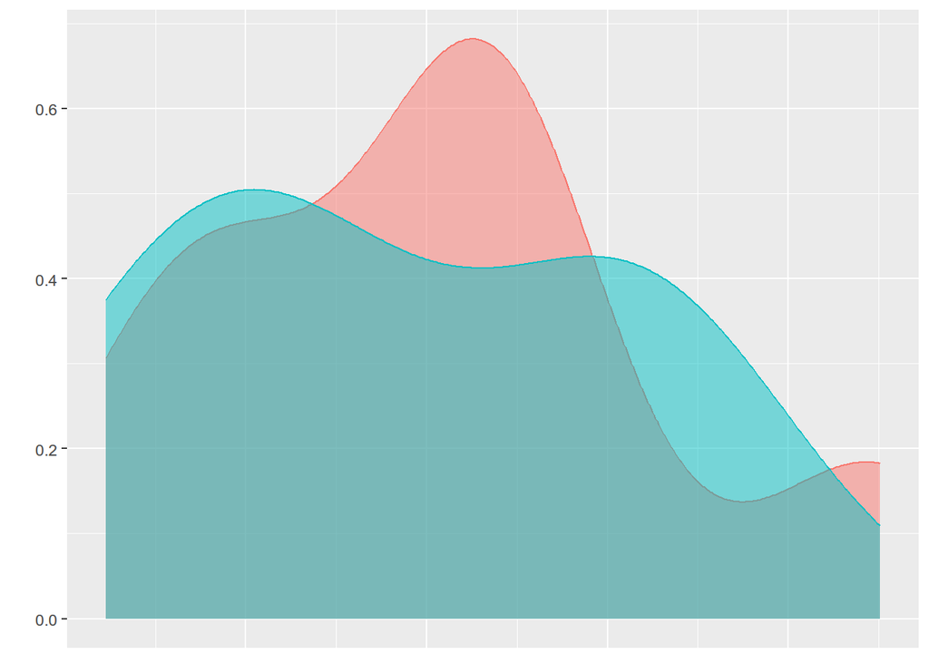

```r
df <- gen_data()
g <- ggplot(df, aes(x=Value, fill=Cat, color=Cat)) +
  geom_density(alpha=.5, show.legend = FALSE) +
  xlab("") +
  ylab("") +
  theme(axis.title.x = element_blank(),
        axis.text.x = element_blank(),
        axis.ticks.x = element_blank())
g
```

# Historgram

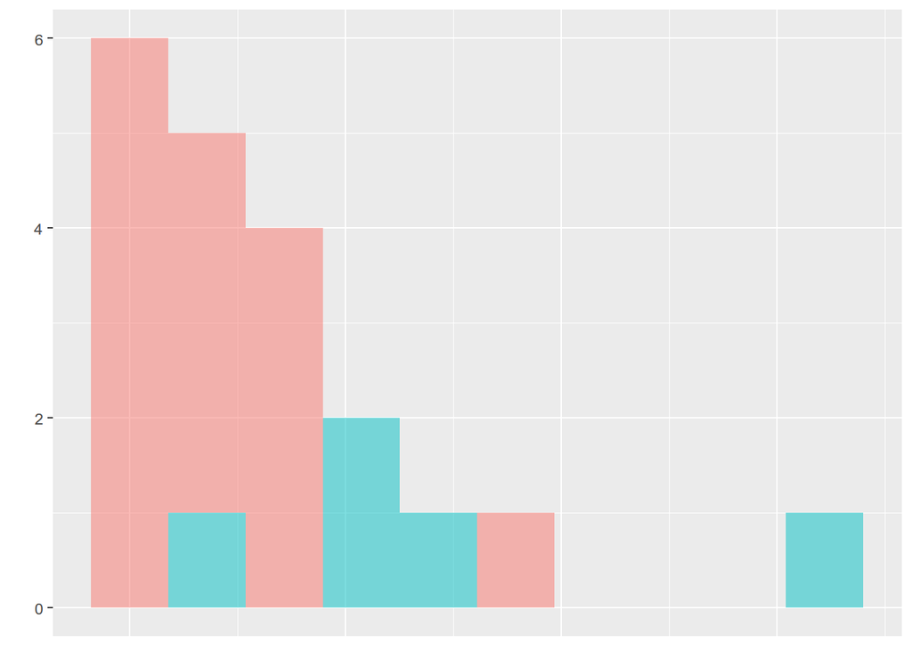

```r
df <- gen_data()
g <- ggplot(df, aes(x=Value, fill = Cat)) +
  geom_histogram(alpha=.5, show.legend = FALSE, bins=10) +
  xlab("") +
  ylab("") +
  theme(axis.title.x = element_blank(),
        axis.text.x = element_blank(),
        axis.ticks.x = element_blank())
g
```

# Dot plot

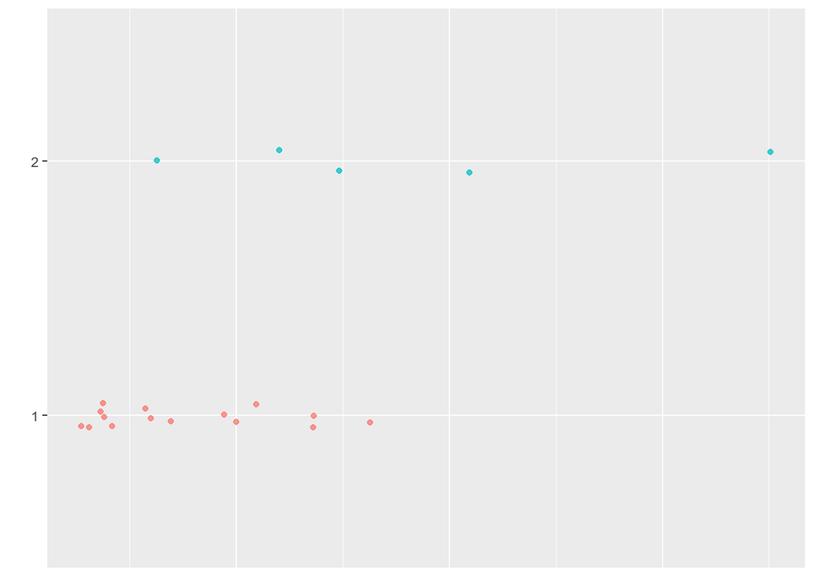

```r
df <- gen_data()
g <- ggplot(df, aes(y = Cat, x = Value, color = Cat)) +
  # geom_point(show.legend = FALSE) +
  geom_jitter(height=0.05, alpha=.75, show.legend = FALSE) +
  xlab("") +
  ylab("") +
  theme(axis.title.x = element_blank(),
        axis.text.x = element_blank(),
        axis.ticks.x = element_blank())
g
```

# Making the null plots

```r
# For dot plots
df <- gen_data()
d <- lineup(null_permute("df"))
```

```
## decrypt("QuCt 1XNX go P4sgNg4o Me")
```

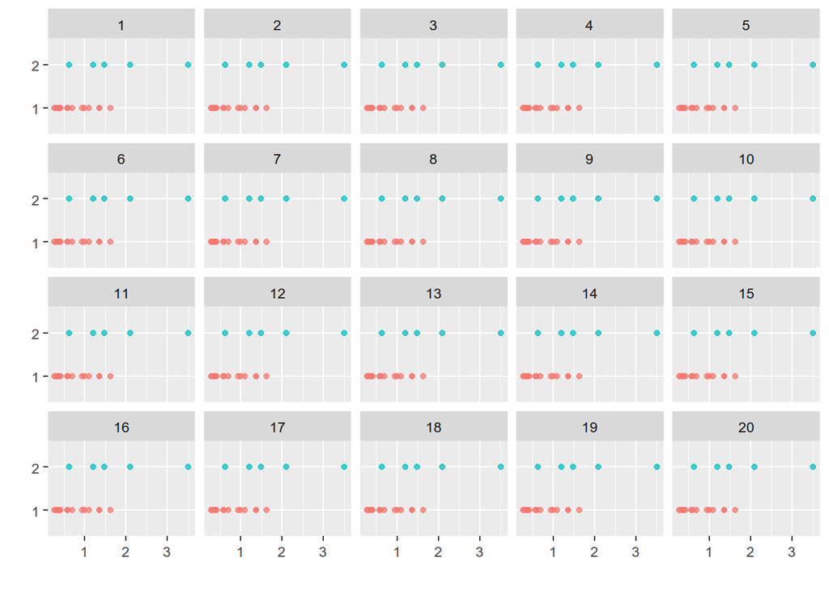

```r
ggplot(data=d,  aes(y = Cat, x = Value, color = Cat)) +
  geom_point(alpha=.75, show.legend = FALSE) +
  xlab("") +
  ylab("") +
  facet_wrap(~ .sample)
```